# User_Satisfaction_Analysis

## **Task #3**

Analyzing survey data of user satisfaction levels.

### 📊Customer Satisfaction Dataset

The first step would be importing a customized dataset 📁 in CSV format, depicting six columns with information about customer's 🧑‍💼 ID, gender 👤, product category 🛍️, purchase amount 💰, and satisfaction levels 😊 (I have customized it to 150 rows 🔢).

The customer satisfaction survey 🧪 has five levels, namely:

- 😍 Very Satisfied
- 🙂 Satisfied
- 😐 Neutral
- 🙁 Dissatisfied
- 😡 Very Dissatisfied

### ⚒️Tools Utilized

- 🤖 ChatGPT (for customization of dataset)
- 🐍 Python (for data processing and analysis)
- 🐼 Pandas library (for importing/loading dataset)
- 📊 Matplotlib library (for data labelling) and Seaborn (for plotting and visualization)

### 🔑Key Concepts

- Data visualization, groupby().size(), value_counts(), unstack(fill_value=0), stacked barplot(), xlabel(), ylabel(), title(), legend()

```python
import pandas as pd
customer_satisfaction_dataset = pd.read_csv("/content/user_satisfaction_150.csv")
customer_satisfaction_dataset
```

|  | user_id | age | gender | product_category | purchase_amount | satisfaction |
| --- | --- | --- | --- | --- | --- | --- |
| 0 | 1 | 24 | Male | Electronics | 145.50 | Very Satisfied |
| 1 | 2 | 31 | Female | Clothing | 78.20 | Satisfied |
| 2 | 3 | 22 | Male | Groceries | 34.10 | Neutral |
| 3 | 4 | 45 | Female | Electronics | 210.00 | Dissatisfied |
| 4 | 5 | 29 | Male | Clothing | 56.75 | Very Dissatisfied |
| ... | ... | ... | ... | ... | ... | ... |
| 145 | 146 | 36 | Female | Clothing | 83.70 | Very Dissatisfied |
| 146 | 147 | 27 | Male | Groceries | 47.90 | Satisfied |
| 147 | 148 | 43 | Female | Electronics | 205.40 | Very Satisfied |
| 148 | 149 | 35 | Male | Clothing | 65.10 | Neutral |
| 149 | 150 | 30 | Female | Groceries | 59.60 | Dissatisfied |

150 rows × 6 columns

🔍 Let’s count the satisfaction levels selected by customers.

> 📌The **value_counts()** function counts how many times each value appears in a column.

💡 It is especially useful for analyzing survey data and understanding response distribution.

```python
satisfied_user_count = customer_satisfaction_dataset["satisfaction"].value_counts()
satisfied_user_count
```

| satisfaction | count |
| --- | --- |
| Very Satisfied | 49 |
| Neutral | 38 |
| Satisfied | 31 |
| Dissatisfied | 21 |
| Very Dissatisfied | 11 |

**dtype:** int64

## 📈 Visualizing Satisfaction Data:

📊 Now that we understand the value counts, we can easily visualize this data using powerful data visualization libraries.

🚀 Commonly used libraries include:

- 📉 Matplotlib
- 🎨 Seaborn

We will plot using seaborn and customize/label it with matplotlib.

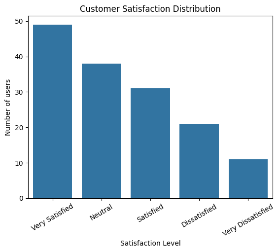

```python
import seaborn as sns
import matplotlib.pyplot as plt
sns.barplot(x =satisfied_user_count.index,  y= satisfied_user_count.values) # .index gives us the names/labels & .values gives us the actual values/data
plt.title("Customer Satisfaction Distribution")
plt.xlabel("Satisfaction Level")
plt.ylabel("Number of users")
plt.xticks(rotation = 30) # To avoid smudging of x-axis data labels
plt.show()
```

We can also further slice this dataset for deep insights, like:

- 👥 Gender-wise satisfaction levels
- 🛍️ Category-wise satisfaction levels
- 🎂 Age-wise satisfaction levels

In this way we can further narrow down specific customers and cater their problems by targeted data-driven solutions.

### 🛒Customer Satisfaction by Age Group

Let’s analyze the customer satisfaction by age group and gain insights into customer behavior.

> 💡This can help target marketing strategies with respect to age segments.

```python
customer_by_age =customer_satisfaction_dataset["age"].value_counts()
customer_by_age
```

| age | count |
| --- | --- |
| 28 | 9 |
| 27 | 8 |
| 29 | 8 |
| 41 | 8 |
| 36 | 7 |
| 31 | 7 |
| 30 | 7 |
| 35 | 7 |
| 33 | 6 |
| 34 | 6 |
| 45 | 6 |
| 26 | 6 |
| 37 | 6 |
| 38 | 6 |
| 44 | 5 |
| 25 | 5 |
| 32 | 5 |
| 39 | 5 |
| 42 | 4 |
| 24 | 4 |
| 48 | 4 |
| 40 | 4 |
| 47 | 3 |
| 43 | 3 |
| 46 | 2 |
| 22 | 2 |
| 23 | 2 |
| 49 | 2 |
| 52 | 1 |
| 21 | 1 |
| 50 | 1 |

**dtype:** int64

### 👥Grouping Customers by Age & Satisfaction

We can group the customers of same age based on satisfaction.

- .groupby() will put same age group with same satisfaction level into one group
- .size() will count how many of same age group have same satisfaction level 🔢.

> 💡 This will helps us see exactly how many people of each age have same satisfaction level 📊

```python
age_satisfaction = customer_satisfaction_dataset.groupby(["age", "satisfaction"]).size()
age_satisfaction
```

| age | satisfaction | 0 |
| --- | --- | --- |
| 21 | Very Dissatisfied | 1 |
| 22 | Neutral | 1 |
|  | Very Dissatisfied | 1 |
| 23 | Satisfied | 1 |
|  | Very Dissatisfied | 1 |
| ... | ... | ... |
| 48 | Very Satisfied | 4 |
| 49 | Satisfied | 1 |
|  | Very Satisfied | 1 |
| 50 | Very Satisfied | 1 |
| 52 | Neutral | 1 |

83 rows × 1 columns

**dtype:** int64

### 📊Making the Table Readable for Visualization

We can reshape our grouped data for better readability and plotting:

- .unstack() converts a row index into column index, making the table easier to read 🗂️
- fill_value=0 replaces missing or NaN values with 0.

```python
age_satisfaction = customer_satisfaction_dataset.groupby(["age", "satisfaction"]).size().unstack(fill_value=0)
age_satisfaction
```

| satisfaction age | Dissatisfied | Neutral | Satisfied | Very Dissatisfied | Very Satisfied |
| --- | --- | --- | --- | --- | --- |
| 21 | 0 | 0 | 0 | 1 | 0 |
| 22 | 0 | 1 | 0 | 1 | 0 |
| 23 | 0 | 0 | 1 | 1 | 0 |
| 24 | 0 | 0 | 1 | 0 | 3 |
| 25 | 0 | 1 | 3 | 0 | 1 |
| 26 | 0 | 1 | 2 | 2 | 1 |
| 27 | 2 | 2 | 3 | 0 | 1 |
| 28 | 2 | 4 | 1 | 0 | 2 |
| 29 | 3 | 1 | 1 | 1 | 2 |
| 30 | 1 | 1 | 0 | 0 | 5 |
| 31 | 0 | 2 | 3 | 0 | 2 |
| 32 | 0 | 2 | 2 | 1 | 0 |
| 33 | 2 | 2 | 1 | 1 | 0 |
| 34 | 1 | 3 | 1 | 0 | 1 |
| 35 | 0 | 6 | 0 | 1 | 0 |
| 36 | 1 | 1 | 2 | 1 | 2 |
| 37 | 1 | 4 | 0 | 1 | 0 |
| 38 | 1 | 0 | 5 | 0 | 0 |
| 39 | 0 | 3 | 0 | 0 | 2 |
| 40 | 1 | 0 | 0 | 0 | 3 |
| 41 | 2 | 0 | 1 | 0 | 5 |
| 42 | 0 | 0 | 1 | 0 | 3 |
| 43 | 0 | 1 | 0 | 0 | 2 |
| 44 | 0 | 0 | 1 | 0 | 4 |
| 45 | 2 | 1 | 1 | 0 | 2 |
| 46 | 1 | 0 | 0 | 0 | 1 |
| 47 | 1 | 1 | 0 | 0 | 1 |
| 48 | 0 | 0 | 0 | 0 | 4 |
| 49 | 0 | 0 | 1 | 0 | 1 |
| 50 | 0 | 0 | 0 | 0 | 1 |
| 52 | 0 | 1 | 0 | 0 | 0 |

### 🔍Bivariate Analysis:

> 💡 Since the data is multidimensional (age × satisfaction x count), a stacked bar chart is the ideal way to visualize it 📈

where, we will have age on x axis, number of customers on y-axis and satisfaction levels stacked along y-axis.

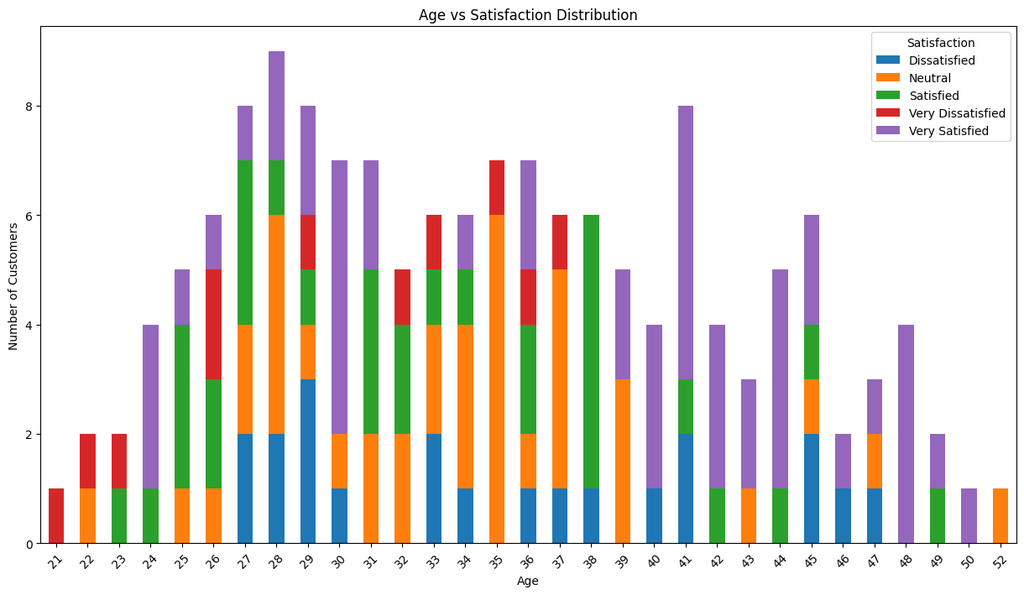

```python
age_satisfaction.plot(kind="bar", stacked=True, figsize=(15,8)) # Bar for vertical bars & barh for horizontal bars.
                                                # we want stacked graph, we write true. If we write false, bars are placed side by side.
plt.title("Age vs Satisfaction Distribution")
plt.xlabel("Age")
plt.ylabel("Number of Customers")
plt.xticks(rotation=45)
plt.legend(title="Satisfaction")


plt.show()
```

### 🔍 Analyzing Other Data Parameters

We can also explore other aspects of the dataset to gain more insights:

- 👪 Data distribution by gender (male and female count)
- 🔤 Data distribution by product_category

💡Understanding these distributions helps identify patterns and trends in customer behavior 📊.

```python
user_count_by_gender = customer_satisfaction_dataset["gender"].value_counts()
user_count_by_gender
```

| gender | count |
| --- | --- |
| Male | 75 |
| Female | 75 |

**dtype:** int64

```python
product_category_count = customer_satisfaction_dataset["product_category"].value_counts()
product_category_count
```

| product_category | count |
| --- | --- |
| Electronics | 50 |
| Clothing | 50 |
| Groceries | 50 |

**dtype:** int64

## 📊Summary:

🔢 Overview  
The dataset mainly consists of:

- Total rows/records: 150 customers
- Features: Age, Gender, Product Category, Purchase Amount, Satisfaction

The bar plot shows that most customers are satisfied with product quality and the value that it offers at the given price.

🔍 **Key Insights**  
😊 📈Customer Satisfaction Trend.

**🧠 Final insights**

💡 The business is performing well:

- Strong satisfaction levels
- Only a small portion of dissatisfaction